# NeuralNetwork slides

## NEURAL NETWORK

### What is Neural Network

#### *It is a good function approximators that based loosely on the ways in which the brain is believed to work*

[figure not shown]

**Figure 1** : **Structure of Neurons Brain**

### Analogy of Artificial Neural Network With Biological Neural Network

[figure not shown]

**Figure 2** : **Artificial Neural Network**  
Analogy of Artificial Neural Network With Biological Neural Network

#### Frank Rosenblatt’s Perceptron

[figure not shown]

[figure not shown]

###### The main idea was to define an algorithm in order to learn the values of the weights w that are then multiplied with the input features in order to make a decision whether a neuron fires or not.

[figure not shown]

##### perceptron can weigh up different kinds of evidence in order to make decisions

#### back then, a perceptron used a activation function (step function) called the *Heaviside step function*

[figure not shown]

##### whose value is zero for negative argument and one for positive argument

- Multi-layer perceptrons are trained using backpropapagation. A requirement for backpropagation is a differentiable activation function. That's because backpropagation uses gradient descent on this function to update the network weights.
- The Heaviside step function is non-differentiable at x = 0 and its derivative is 0 elsewhere. This means gradient descent won't be able to make progress in updating the weights and backpropagation will fail.

### Activation Functions

Activation functions are important component in ANN.

- **It helps the neuron to learn and make sense of something really complicated**
- **Non-linear complex functional mappings between the inputs and response variable. They introduce non-linear properties to our Network.**
- **we'd like a small change in weight to cause only a small corresponding change in the output from the network**

[figure not shown]

#### Sigmoid Function

$$sigmoid(z) = \frac{1}{1 + e^{-z}} $$

[figure not shown]

#### Tanh Function

$$tanh(z) = \frac{e^{z} - e^{-z}}{e^{z} + e^{-z}} $$

[figure not shown]

#### Rectified Linear Unit (ReLU)

$$relu(z) = max(0, z) $$

[figure not shown]

##### why is ReLU non linear?

[figure not shown]

### Generate Prediction (Feedforward)

[figure not shown]

### What does Training mean in NN

**Training in NN means minimizing the cost (how big is the difference between our prediction and the true label)**

- We can define our cost function as: $$J = \sum \frac{1}{2}(Y - Y^{hat})^2$$
- There is some combination of w's that will make our cost J, as small as possible. we have to tweak the weights and bias in order to minimize the cost.

## Learning Algorithms used in Neural Network

### Gradient Descent

*compute the best direction along which we should change our weight vector that is mathematically guaranteed to be the direction of the steepest descend*

[figure not shown]

- by updating the parameters in the opposite direction of the gradient of the objective function **∇θJ(θ)** w.r.t. to the parameters. The learning rate **η** determines the size of the steps we take to reach a (local) minimum.
- In other words, we follow the direction of the slope of the surface created by the objective function downhill until we reach a valley.
- We start off by initializing our weight randomly
- Feedforward, make prediction
- Taking the derivative of W and b with respect to J

[figure not shown]

### Backpropagation

[figure not shown]

$$ \frac{\partial J}{\partial W^{(2)}} = \frac{\partial \sum \frac{1}{2}(y-\hat{y})^2}{\partial W^{(2)}} $$

$$ \frac{\partial J}{\partial W^{(2)}} = -(y-\hat{y}) \frac{\partial \hat{y}}{\partial W^{(2)}} $$

$$ \frac{\partial J}{\partial W^{(2)}} = -(y-\hat{y}) \frac{\partial \hat{y}}{\partial z^{(2)}} \frac{\partial z^{(2)}}{\partial W^{(2)}} $$

*To find the rate of change of yHat with respect to z2, we need to differentiate our sigmoid activation function with respect to z.*
$$ f(z) = \frac{1}{1+e^{-z}} $$
$$ f^\prime(z) = \frac{e^{-z}}{(1+e^{-z})^2} $$

$$ \frac{\partial J}{\partial W^{(2)}}= -(y-\hat{y}) f^\prime(z^{(2)}) \frac{\partial z^{(2)}}{\partial W^{(2)}} $$

$$ z^{(2)} = a^{(1)}W^{(2)} \tag{3}\\ $$

$$ \frac{\partial J}{\partial W^{(2)}}= -(y-\hat{y}) f^\prime(z^{(2)}) a^{(1)} $$

```python
self.y_hat = self.forward(X)
delta2 = np.multiply(- (y - self.y_hat), self.sigmoidPrime(self.z2))
dJdW2 = np.dot(self.a1.T, delta2)
```

[figure not shown]

### Our NN Model for the XOR problem

[figure not shown]

##### Step by Step

- Define our architecture
- Prepare the data
- Initialize the learnable parameters (weights and biases)
- Forward Propagation
- Compute cost
- Backward Propagation
- Update parameters

```python
import matplotlib.pyplot as plt
import numpy as np
import matplotlib

# Display plots inline and change default figure size
%matplotlib inline
matplotlib.rcParams['figure.figsize'] = (10.0, 8.0)
```

```python
# Helper function to plot a decision boundary.
def plot_decision_boundary(pred_func, X, y):
    # Set min and max values and give it some padding
    x_min, x_max = X[:, 0].min() - .5, X[:, 0].max() + .5
    y_min, y_max = X[:, 1].min() - .5, X[:, 1].max() + .5
    h = 0.01
    # Generate a grid of points with distance h between them
    xx, yy = np.meshgrid(np.arange(x_min, x_max, h), np.arange(y_min, y_max, h))
    # Predict the function value for the whole gid
    Z = pred_func(np.c_[xx.ravel(), yy.ravel()])
    Z = Z.reshape(xx.shape)
    # Plot the contour and training examples
    plt.contourf(xx, yy, Z, cmap=plt.cm.Spectral)
    plt.scatter(X[:, 0], X[:, 1], c=y.reshape((4, )), cmap=plt.cm.Spectral)
```

```python
class NN(object):
    def __init__(self, n_x, n_h, n_y, learning_rate=0.01):
        self.learning_rate = learning_rate
        self.W1 = np.random.randn(n_x, n_h)
        self.b1 = np.zeros(shape=(1, n_h))
        self.W2 = np.random.randn(n_h, n_y)
        self.b2 = np.zeros(shape=(1, n_y))
```

```python
def _sigmoid(self, Z):
        return (1 / (1 + np.exp(-Z)))

def feedforward(self, X):
    # first hidden layer
    self.Z1 = np.dot(X, self.W1) + self.b1
    self.A1 = np.tanh(self.Z1)
    # second layer
    self.Z2 = np.dot(self.A1, self.W2) + self.b2
    self.A2 = self._sigmoid(self.Z2)
    return self.A2
```

```python
def compute_cost(self, A2, Y):
    """
    Computes the cross-entropy cost
    """
    m = Y.shape[0] # number of example
    logprobs = np.multiply(np.log(A2), Y) + np.multiply((1 - Y), np.log(1 - A2))
    cost = - np.sum(logprobs) / m
    cost = np.squeeze(cost)     # makes sure cost is the dimension we expect.
    return cost
```

```python
def backprop(self, X, Y):
    m = X.shape[0]

    self.dZ2 = self.A2 - Y


    self.dW2 = (1. / m) * np.dot(self.A1.T, self.dZ2)
    self.db2 = (1. / m) * np.sum(self.dZ2, axis=0, keepdims=True)


    self.dZ1 = np.multiply(np.dot(self.dZ2, self.W2.T ), 1 - np.power(self.A1, 2))
    self.dW1 = (1. / m) * np.dot(X.T, self.dZ1)
    self.db1 = (1. / m) * np.sum(self.dZ1, axis=0, keepdims=True)
```

```python
def update_parameters(self):
    self.W1 -= self.learning_rate * self.dW1
    self.b1 -= self.learning_rate * self.db1
    self.W2 -= self.learning_rate * self.dW2
    self.b2 -= self.learning_rate * self.db2
```

```python
def predict(self, X):
    A2 = self.feedforward(X)
    predictions = np.round(A2)
    return predictions
```

```python
X = np.array([[0, 0],
                  [0, 1],
                  [1, 0],
                  [1, 1]])
y = np.array([[0,1,1,0]]).T
```

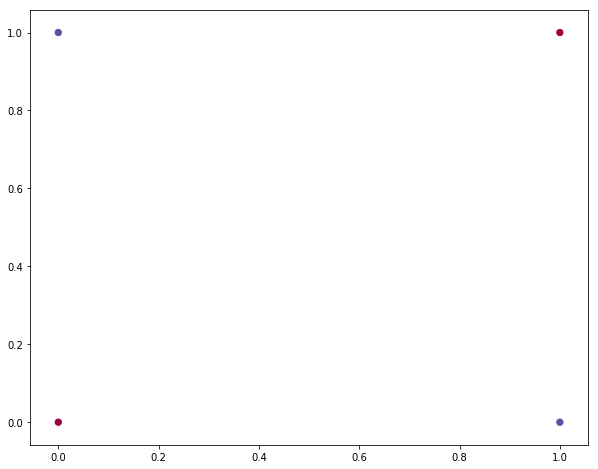

```python
plt.scatter(X[:,0], X[:,1], s=40, c=y.reshape((4, )), cmap=plt.cm.Spectral)
```

```python
def build_model(X, y, num_hidden, learning_rate=0.01, num_iterations=50000, verbose=True):
    model = NN(n_x=2, n_h=num_hidden, n_y=1, learning_rate=learning_rate)
    cost_history = []
    for i in range(0, num_iterations):
        A2 = model.feedforward(X)
        cost = model.compute_cost(A2, y)
        model.backprop(X, y)
        model.update_parameters()
        if i % 1000 == 0 and verbose:
            print ("Iteration %i Cost: %f" % (i, cost))

        cost_history.append(cost)
    return model, cost_history
```

```python
model, _ = build_model(X, y, 3, num_iterations=9500)
```

```
Iteration 0 Cost: 0.706706
Iteration 1000 Cost: 0.654264
Iteration 2000 Cost: 0.575510
Iteration 3000 Cost: 0.469847
Iteration 4000 Cost: 0.350015
Iteration 5000 Cost: 0.236700
Iteration 6000 Cost: 0.158161
Iteration 7000 Cost: 0.111532
Iteration 8000 Cost: 0.083616
Iteration 9000 Cost: 0.065883
```

```
Text(0.5,1,u'Neural Networks with 3 neurons')
```

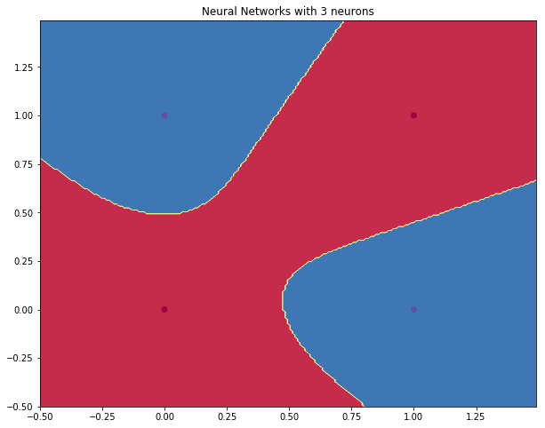

```python
plot_decision_boundary(lambda x: model.predict(x), X, y)
plt.title("Neural Networks with 3 neurons")
```

```python
model, _ = build_model(X, y, 2) # 2 Neurons in our hidden layer
```

```
Iteration 0 Cost: 0.757981
Iteration 1000 Cost: 0.605591
Iteration 2000 Cost: 0.520218
Iteration 3000 Cost: 0.410372
Iteration 4000 Cost: 0.265787
Iteration 5000 Cost: 0.171179
Iteration 6000 Cost: 0.120664
Iteration 7000 Cost: 0.091530
Iteration 8000 Cost: 0.073090
Iteration 9000 Cost: 0.060537
Iteration 10000 Cost: 0.051507
Iteration 11000 Cost: 0.044732
Iteration 12000 Cost: 0.039477
Iteration 13000 Cost: 0.035292
Iteration 14000 Cost: 0.031885
Iteration 15000 Cost: 0.029062
Iteration 16000 Cost: 0.026685
Iteration 17000 Cost: 0.024660
Iteration 18000 Cost: 0.022913
Iteration 19000 Cost: 0.021392
Iteration 20000 Cost: 0.020057
Iteration 21000 Cost: 0.018875
Iteration 22000 Cost: 0.017823
Iteration 23000 Cost: 0.016879
Iteration 24000 Cost: 0.016029
Iteration 25000 Cost: 0.015259
Iteration 26000 Cost: 0.014558
Iteration 27000 Cost: 0.013918
Iteration 28000 Cost: 0.013331
Iteration 29000 Cost: 0.012790
Iteration 30000 Cost: 0.012291
Iteration 31000 Cost: 0.011829
Iteration 32000 Cost: 0.011401
Iteration 33000 Cost: 0.011001
Iteration 34000 Cost: 0.010629
Iteration 35000 Cost: 0.010280
Iteration 36000 Cost: 0.009953
Iteration 37000 Cost: 0.009646
Iteration 38000 Cost: 0.009358
Iteration 39000 Cost: 0.009086
Iteration 40000 Cost: 0.008829
Iteration 41000 Cost: 0.008586
Iteration 42000 Cost: 0.008356
Iteration 43000 Cost: 0.008138
Iteration 44000 Cost: 0.007930
Iteration 45000 Cost: 0.007733
Iteration 46000 Cost: 0.007546
Iteration 47000 Cost: 0.007367
Iteration 48000 Cost: 0.007196
Iteration 49000 Cost: 0.007033
```

```
Text(0.5,1,u'Neural Networks with 2 neurons')
```

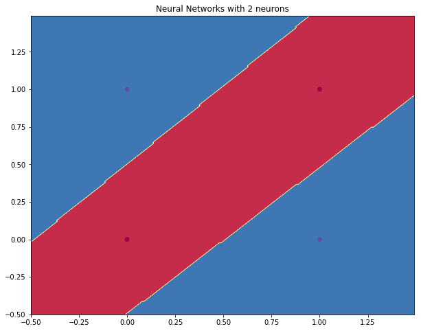

```python
# Plot the decision boundary
plot_decision_boundary(lambda x: model.predict(x), X, y)
plt.title("Neural Networks with 2 neurons")
```

```python
model, _ = build_model(X, y, 4) # 4 neurons in a hidden layer
```

```
Iteration 0 Cost: 0.915663
Iteration 1000 Cost: 0.526426
Iteration 2000 Cost: 0.444497
Iteration 3000 Cost: 0.332683
Iteration 4000 Cost: 0.216390
Iteration 5000 Cost: 0.139040
Iteration 6000 Cost: 0.095075
Iteration 7000 Cost: 0.069907
Iteration 8000 Cost: 0.054508
Iteration 9000 Cost: 0.044389
Iteration 10000 Cost: 0.037326
Iteration 11000 Cost: 0.032152
Iteration 12000 Cost: 0.028215
Iteration 13000 Cost: 0.025125
Iteration 14000 Cost: 0.022639
Iteration 15000 Cost: 0.020597
Iteration 16000 Cost: 0.018891
Iteration 17000 Cost: 0.017445
Iteration 18000 Cost: 0.016205
Iteration 19000 Cost: 0.015128
Iteration 20000 Cost: 0.014186
Iteration 21000 Cost: 0.013354
Iteration 22000 Cost: 0.012614
Iteration 23000 Cost: 0.011952
Iteration 24000 Cost: 0.011356
Iteration 25000 Cost: 0.010816
Iteration 26000 Cost: 0.010326
Iteration 27000 Cost: 0.009878
Iteration 28000 Cost: 0.009467
Iteration 29000 Cost: 0.009090
Iteration 30000 Cost: 0.008741
Iteration 31000 Cost: 0.008418
Iteration 32000 Cost: 0.008118
Iteration 33000 Cost: 0.007839
Iteration 34000 Cost: 0.007578
Iteration 35000 Cost: 0.007335
Iteration 36000 Cost: 0.007106
Iteration 37000 Cost: 0.006891
Iteration 38000 Cost: 0.006689
Iteration 39000 Cost: 0.006499
Iteration 40000 Cost: 0.006319
Iteration 41000 Cost: 0.006148
Iteration 42000 Cost: 0.005987
Iteration 43000 Cost: 0.005834
Iteration 44000 Cost: 0.005688
Iteration 45000 Cost: 0.005550
Iteration 46000 Cost: 0.005418
Iteration 47000 Cost: 0.005293
Iteration 48000 Cost: 0.005173
Iteration 49000 Cost: 0.005058
```

```
Text(0.5,1,u'Neural Networks with 4 neurons')
```

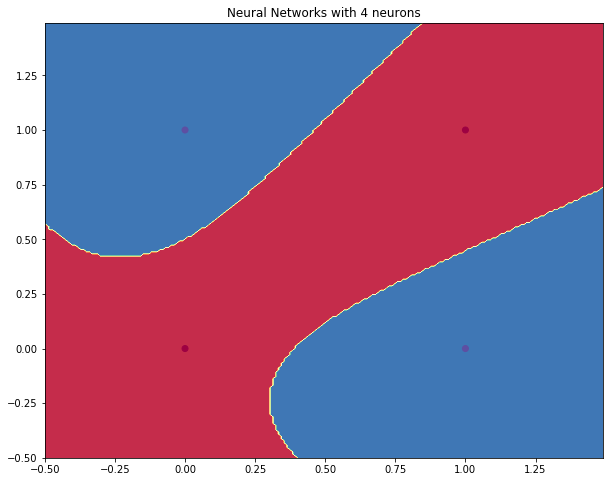

```python
# Plot the decision boundary
plot_decision_boundary(lambda x: model.predict(x), X, y)
plt.title("Neural Networks with 4 neurons")
```

## Deep Learning?

[figure not shown]

### The problem of very deep neural networks

Theoritically, the main benefit of a very deep network is that it can **represent very complex functions**. Specifically, by using a deeper architecture, we can learn features at many different levels of abstraction, from edges (at the lower layers) to very complex features (at the deeper layers).

However, using a deeper network doesn't always help in practice. The biggest problem that we will encounter when training a deeper network is the *vanishing gradients* problem: a condition where a very deep networks often have a gradient signal that goes to zero quickly, thus making gradient descent unbearably slow.

More specifically, during gradient descent, as we backprop from the final layer back to the first layer, we are multiplying by the weight matrix on each step, and thus the gradient can decrease exponentially quickly to zero or, in rare cases, grow exponentially quickly and "explode" to take very large values.

[figure not shown]

**Vanishing gradient**  
The speed of learning decreases very rapidly for the early layers as the network trains